# ds

Autogenerated data summary from dataMaid

2021-08-22 20:34:39

# Data report overview

The dataset examined has the following dimensions:

| Feature | Result |
| --- | --- |
| Number of observations | 235354 |
| Number of variables | 158 |

### Checks performed

The following variable checks were performed, depending on the data type of each variable:

|  | character | factor | labelled | haven labelled | numeric | integer | logical | Date |
| --- | --- | --- | --- | --- | --- | --- | --- | --- |
| Identify miscoded missing values | × | × | × | × | × | × |  | × |
| Identify prefixed and suffixed whitespace | × | × | × | × |  |  |  |  |
| Identify levels with < 6 obs. | × | × | × | × |  |  |  |  |
| Identify case issues | × | × | × | × |  |  |  |  |
| Identify misclassified numeric or integer variables | × | × | × | × |  |  |  |  |
| Identify outliers |  |  |  |  | × | × |  | × |

Please note that all numerical values in the following have been rounded to 2 decimals.

# Summary table

|  | Variable class | # unique values | Missing observations | Any problems? |
| --- | --- | --- | --- | --- |
| numero_de_cliente | integer | 235354 | 0.00 % |  |
| foto_mes | integer | 1 | 0.00 % | × |
| active_quarter | integer | 2 | 0.00 % |  |
| cliente_vip | integer | 2 | 0.00 % |  |
| internet | integer | 2 | 0.00 % |  |
| cliente_edad | integer | 80 | 0.00 % | × |
| cliente_antiguedad | integer | 317 | 0.00 % |  |
| mrentabilidad | numeric | 195551 | 0.00 % | × |
| mrentabilidad_annual | numeric | 230055 | 0.00 % | × |
| mcomisiones | numeric | 146624 | 0.00 % | × |
| mactivos_margen | numeric | 166075 | 0.00 % | × |
| mpasivos_margen | numeric | 147273 | 0.00 % | × |
| cproductos | integer | 16 | 0.00 % | × |
| tpaquete1 | integer | 1 | 0.00 % | × |
| tpaquete3 | integer | 2 | 0.00 % |  |
| tpaquete4 | integer | 2 | 0.00 % |  |
| tcuentas | integer | 2 | 0.00 % |  |
| ccuenta_corriente | integer | 4 | 0.00 % | × |
| mcuenta_corriente_adicional | numeric | 137 | 0.00 % | × |
| mcuenta_corriente | numeric | 93390 | 0.00 % | × |
| ccaja_ahorro | integer | 10 | 0.00 % | × |
| mcaja_ahorro | numeric | 214768 | 0.00 % | × |
| mcaja_ahorro_adicional | numeric | 5325 | 0.00 % | × |
| mcaja_ahorro_dolares | numeric | 65192 | 0.00 % | × |
| mdescubierto_preacordado | numeric | 2 | 0.00 % |  |
| mcuentas_saldo | numeric | 229001 | 0.00 % | × |
| ctarjeta_debito | integer | 16 | 0.00 % | × |
| ctarjeta_debito_transacciones | integer | 113 | 0.00 % | × |
| mautoservicio | numeric | 131125 | 0.00 % | × |
| ctarjeta_visa | integer | 5 | 0.00 % | × |

[output cut: 128 more lines]

# Variable list

## numero_de_cliente

| Feature | Result |
| --- | --- |
| Variable type | integer |
| Number of missing obs. | 0 (0 %) |
| Number of unique values | 235354 |
| Median | 24406655.5 |
| 1st and 3rd quartiles | 15663196; 35413715.25 |
| Min. and max. | 4572294; 60887355 |

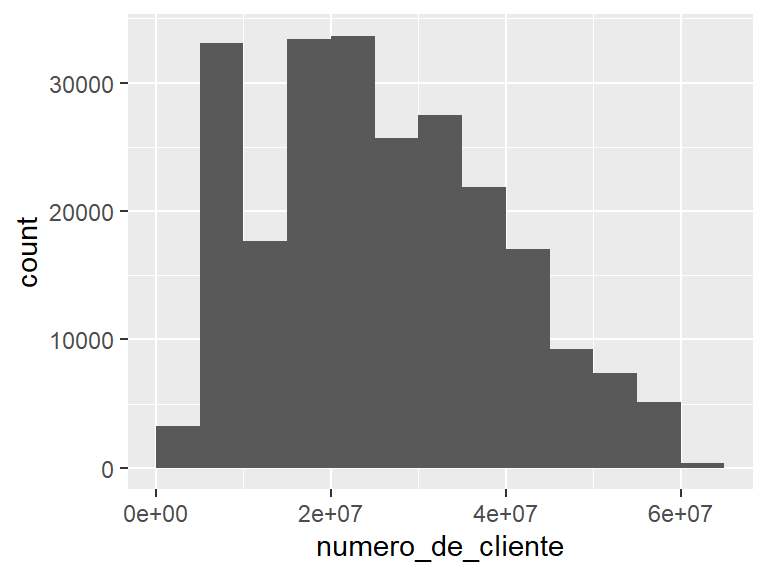

## foto_mes

- The variable only takes one (non-missing) value: “202009”. The variable contains 0 % missing observations.

## active_quarter

- Note that this variable is treated as a factor variable below, as it only takes a few unique values.

| Feature | Result |
| --- | --- |
| Variable type | integer |
| Number of missing obs. | 0 (0 %) |
| Number of unique values | 2 |
| Mode | “1” |
| Reference category | 0 |

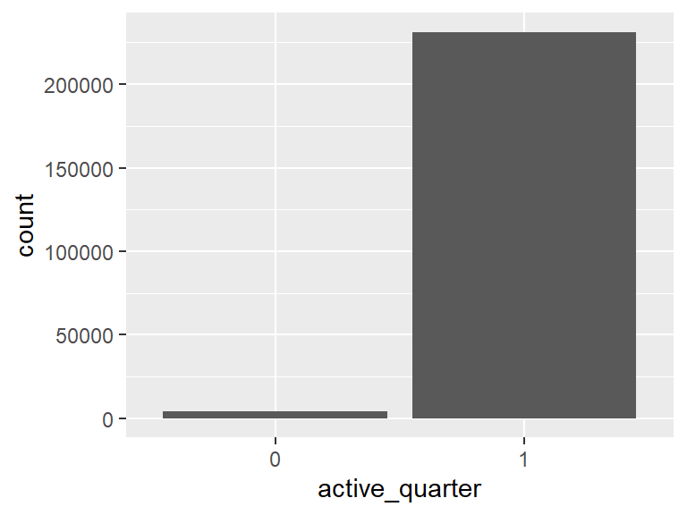

## cliente_vip

- Note that this variable is treated as a factor variable below, as it only takes a few unique values.

| Feature | Result |
| --- | --- |
| Variable type | integer |
| Number of missing obs. | 0 (0 %) |
| Number of unique values | 2 |
| Mode | “0” |
| Reference category | 0 |

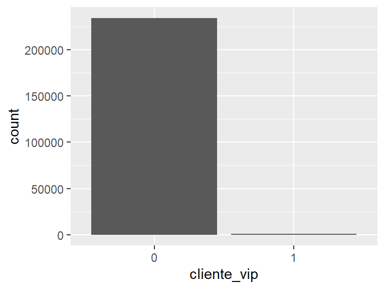

## internet

- Note that this variable is treated as a factor variable below, as it only takes a few unique values.

| Feature | Result |
| --- | --- |
| Variable type | integer |
| Number of missing obs. | 0 (0 %) |
| Number of unique values | 2 |
| Mode | “1” |
| Reference category | 0 |

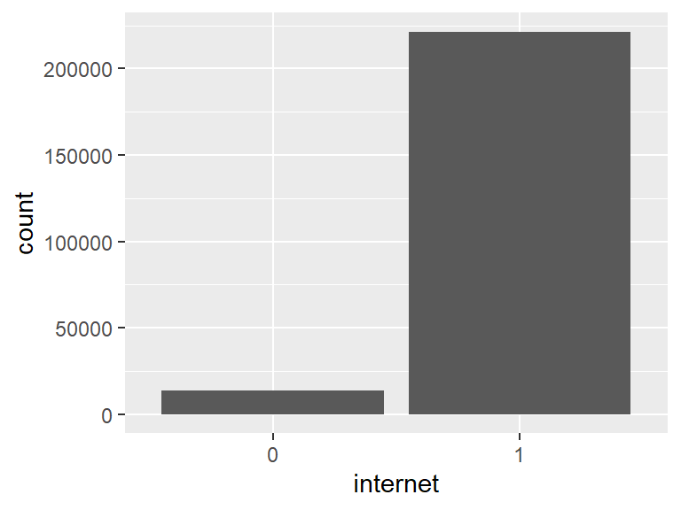

## cliente_edad

| Feature | Result |
| --- | --- |
| Variable type | integer |
| Number of missing obs. | 0 (0 %) |
| Number of unique values | 80 |
| Median | 45 |
| 1st and 3rd quartiles | 37; 55 |
| Min. and max. | 18; 97 |

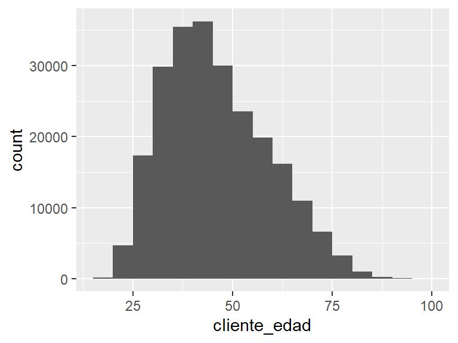

- Note that the following possible outlier values were detected: “18”, “19”, “20”, “21”, “97”.

## cliente_antiguedad

| Feature | Result |
| --- | --- |
| Variable type | integer |
| Number of missing obs. | 0 (0 %) |
| Number of unique values | 317 |
| Median | 123 |
| 1st and 3rd quartiles | 59; 184 |
| Min. and max. | 1; 369 |

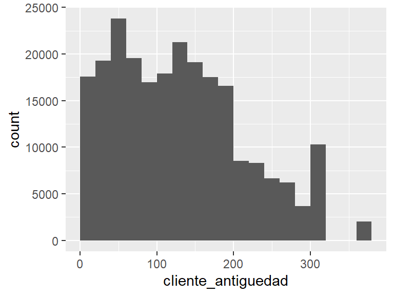

## mrentabilidad

| Feature | Result |
| --- | --- |
| Variable type | numeric |
| Number of missing obs. | 0 (0 %) |
| Number of unique values | 195551 |
| Median | 1069.2 |
| 1st and 3rd quartiles | 83.63; 2723.42 |
| Min. and max. | -355437.47; 605304.5 |

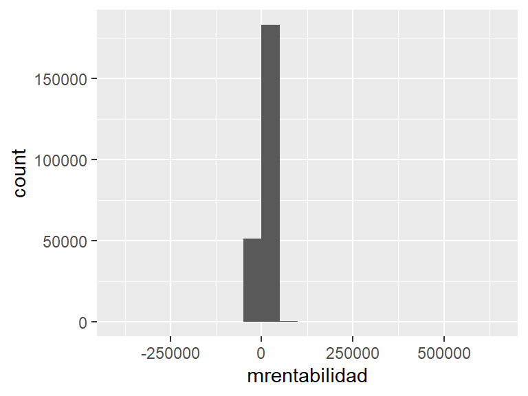

- Note that the following possible outlier values were detected: “-355437.47”, “-140194.7”, “-122039.56”, “-86700.35”, “-76513.02”, “-72482.41”, “-70626.71”, “-62400”, “-59172.67”, “-57116.4” (27040 additional values omitted).

## mrentabilidad_annual

| Feature | Result |
| --- | --- |
| Variable type | numeric |
| Number of missing obs. | 0 (0 %) |
| Number of unique values | 230055 |
| Median | 14720.65 |
| 1st and 3rd quartiles | 3984.21; 31971.92 |
| Min. and max. | -2079330.98; 8742163.98 |

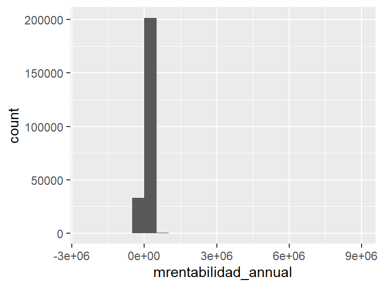

- Note that the following possible outlier values were detected: “-2079330.98”, “-669319.85”, “-574984.63”, “-522768.07”, “-465464.51”, “-464365”, “-447130.11”, “-425898.7”, “-408424.37”, “-407570.78” (18973 additional values omitted).

## mcomisiones

| Feature | Result |
| --- | --- |
| Variable type | numeric |
| Number of missing obs. | 0 (0 %) |
| Number of unique values | 146624 |
| Median | 702.54 |
| 1st and 3rd quartiles | 240.71; 1581.77 |
| Min. and max. | -243252.69; 264726.31 |

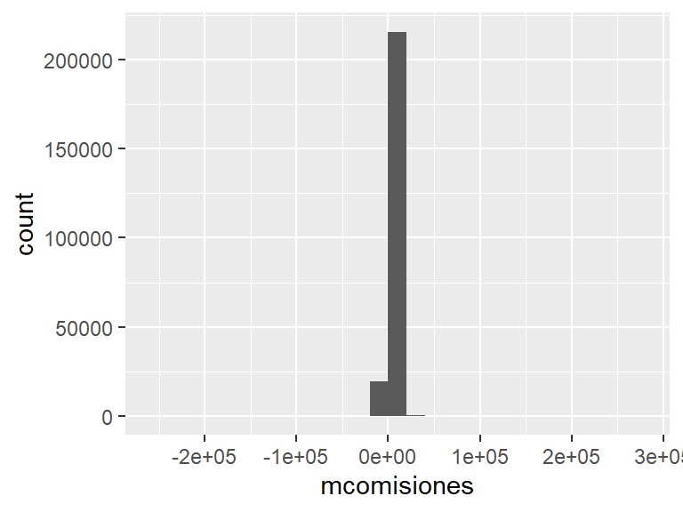

- Note that the following possible outlier values were detected: “-243252.69”, “-130560.93”, “-44231.6”, “-38800.92”, “-26524.46”, “-25383.07”, “-24273.06”, “-22151.71”, “-21710.84”, “-16730.28” (7043 additional values omitted).

## mactivos_margen

| Feature | Result |
| --- | --- |
| Variable type | numeric |
| Number of missing obs. | 0 (0 %) |
| Number of unique values | 166075 |
| Median | -231 |
| 1st and 3rd quartiles | -1015.23; 31.01 |
| Min. and max. | -114949.31; 190050.48 |

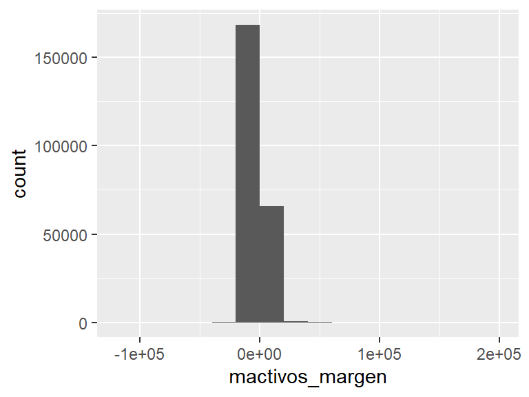

- Note that the following possible outlier values were detected: “-114949.31”, “-113135.42”, “-104398.43”, “-74278.81”, “-71777.59”, “-69862.84”, “-68891.58”, “-63599.48”, “-63225.64”, “-59409.2” (39820 additional values omitted).

## mpasivos_margen

| Feature | Result |
| --- | --- |
| Variable type | numeric |
| Number of missing obs. | 0 (0 %) |
| Number of unique values | 147273 |
| Median | 437.83 |
| 1st and 3rd quartiles | 130.69; 1124.93 |
| Min. and max. | -119876.81; 304146.85 |

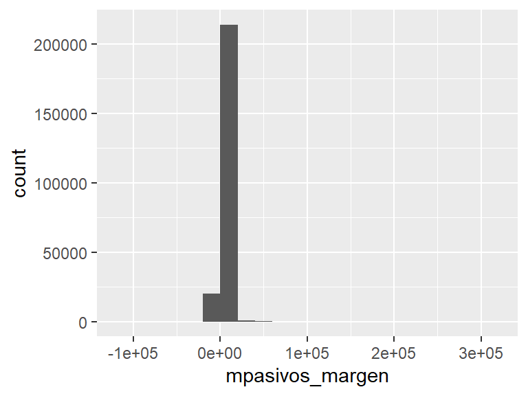

- Note that the following possible outlier values were detected: “-119876.81”, “-73610.05”, “-66724.1”, “-59821.48”, “-53333.34”, “-44985.43”, “-39133.78”, “-38961.79”, “-38498.02”, “-38202.5” (20967 additional values omitted).

## cproductos

| Feature | Result |
| --- | --- |
| Variable type | integer |
| Number of missing obs. | 0 (0 %) |
| Number of unique values | 16 |
| Median | 7 |
| 1st and 3rd quartiles | 7; 8 |
| Min. and max. | 3; 18 |

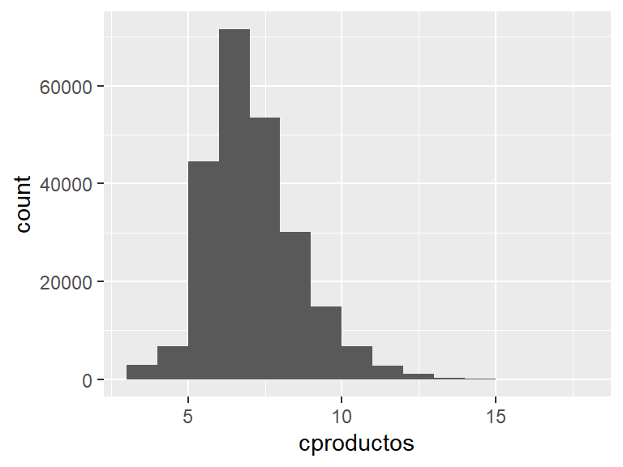

- Note that the following possible outlier values were detected: “3”, “4”, “5”, “6”, “15”, “16”, “17”, “18”.

## tpaquete1

- The variable only takes one (non-missing) value: “1”. The variable contains 0 % missing observations.

## tpaquete3

- Note that this variable is treated as a factor variable below, as it only takes a few unique values.

| Feature | Result |
| --- | --- |
| Variable type | integer |
| Number of missing obs. | 0 (0 %) |
| Number of unique values | 2 |
| Mode | “0” |
| Reference category | 0 |

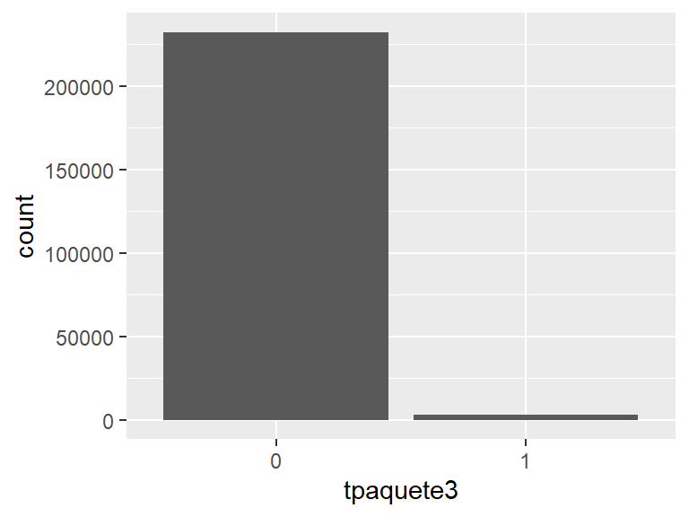

## tpaquete4

- Note that this variable is treated as a factor variable below, as it only takes a few unique values.

| Feature | Result |
| --- | --- |
| Variable type | integer |
| Number of missing obs. | 0 (0 %) |
| Number of unique values | 2 |
| Mode | “0” |
| Reference category | 0 |

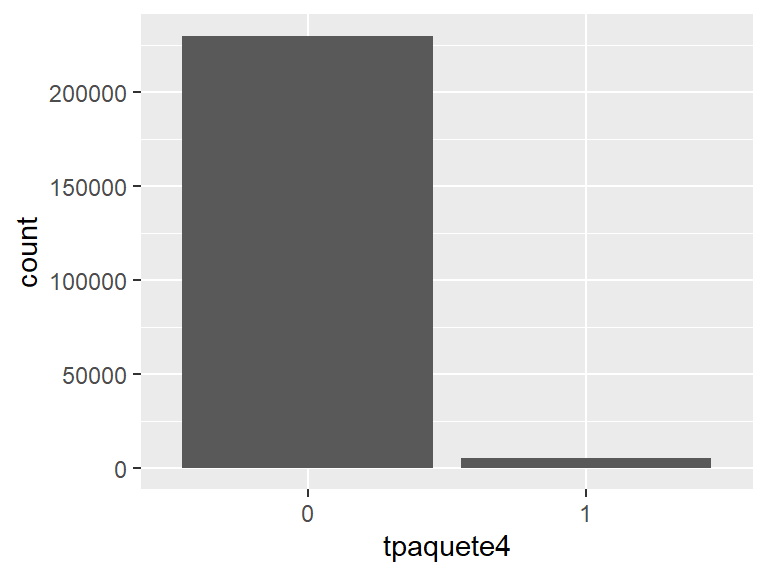

## tcuentas

- Note that this variable is treated as a factor variable below, as it only takes a few unique values.

| Feature | Result |
| --- | --- |
| Variable type | integer |
| Number of missing obs. | 0 (0 %) |
| Number of unique values | 2 |
| Mode | “1” |
| Reference category | 1 |

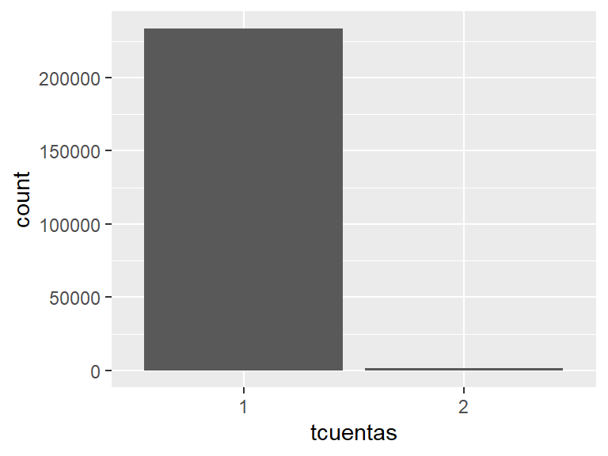

## ccuenta_corriente

- Note that this variable is treated as a factor variable below, as it only takes a few unique values.

| Feature | Result |
| --- | --- |
| Variable type | integer |
| Number of missing obs. | 0 (0 %) |
| Number of unique values | 4 |
| Mode | “1” |
| Reference category | 1 |

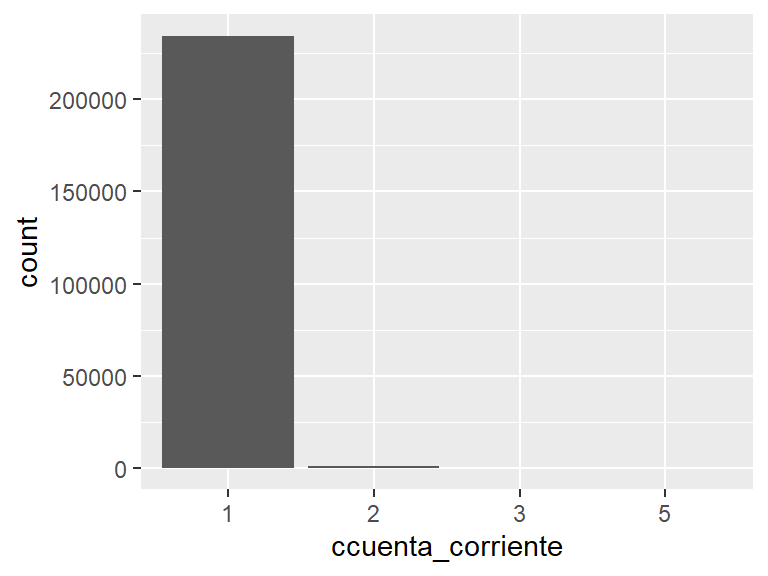

- Note that the following levels have at most five observations: “5”.

## mcuenta_corriente_adicional

| Feature | Result |
| --- | --- |
| Variable type | numeric |
| Number of missing obs. | 0 (0 %) |
| Number of unique values | 137 |
| Median | 0 |
| 1st and 3rd quartiles | 0; 0 |
| Min. and max. | -12065.22; 18671602.75 |

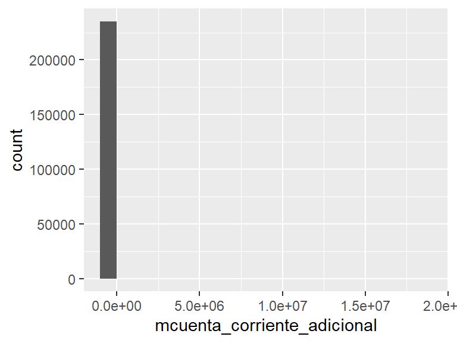

- Note that the following possible outlier values were detected: “-12065.22”, “-11217.14”, “-6656.28”, “-2332.41”, “-1851.99”, “-1841.43”, “-1716.08”, “-1574.3”, “-1273.46”, “-735.56” (126 additional values omitted).

## mcuenta_corriente

| Feature | Result |
| --- | --- |
| Variable type | numeric |
| Number of missing obs. | 0 (0 %) |
| Number of unique values | 93390 |
| Median | 0 |
| 1st and 3rd quartiles | -474.06; 0 |
| Min. and max. | -20807360.61; 19766511.21 |

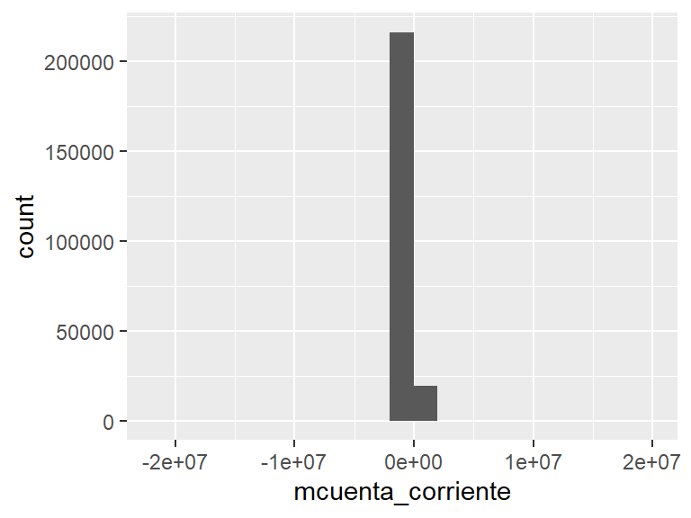

- Note that the following possible outlier values were detected: “-20807360.61”, “-2713005.61”, “-2060485.11”, “-1690102.15”, “-1452698.33”, “-1411843.05”, “-1389578.86”, “-1279503.66”, “-1277894.8”, “-1096366.24” (23384 additional values omitted).

## ccaja_ahorro

| Feature | Result |
| --- | --- |
| Variable type | integer |
| Number of missing obs. | 0 (0 %) |
| Number of unique values | 10 |
| Median | 2 |
| 1st and 3rd quartiles | 2; 2 |
| Min. and max. | 2; 12 |

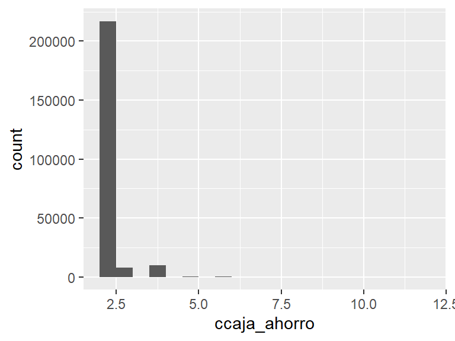

- Note that the following possible outlier values were detected: “3”, “4”, “5”, “6”, “7”, “8”, “9”, “10”, “12”.

## mcaja_ahorro

| Feature | Result |
| --- | --- |
| Variable type | numeric |
| Number of missing obs. | 0 (0 %) |
| Number of unique values | 214768 |
| Median | 18348.46 |
| 1st and 3rd quartiles | 4607; 56002.16 |
| Min. and max. | -1360.44; 20138914.75 |

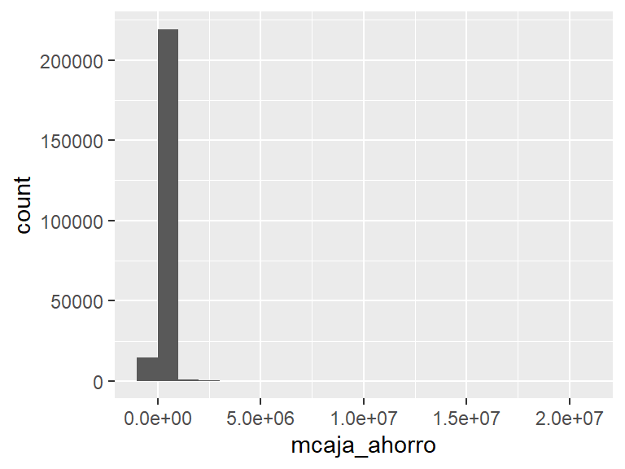

- Note that the following possible outlier values were detected: “461304.53”, “461315.06”, “461423.19”, “461483.36”, “461514.15”, “461747.92”, “461757.1”, “461783.66”, “461789.13”, “461844.85” (5399 additional values omitted).

## mcaja_ahorro_adicional

| Feature | Result |
| --- | --- |
| Variable type | numeric |
| Number of missing obs. | 0 (0 %) |
| Number of unique values | 5325 |
| Median | 0 |
| 1st and 3rd quartiles | 0; 0 |
| Min. and max. | -13993.16; 2426196.33 |

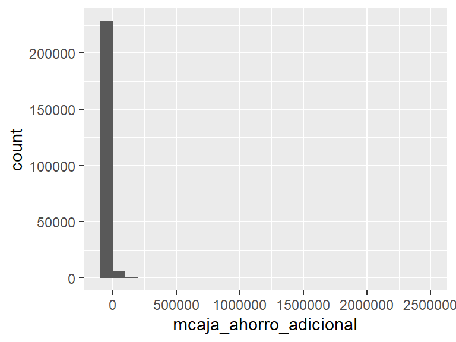

- Note that the following possible outlier values were detected: “-13993.16”, “-4346.63”, “-508.89”, “-200.86”, “-20.72”, “0.01”, “0.02”, “0.03”, “0.04”, “0.05” (5314 additional values omitted).

## mcaja_ahorro_dolares

| Feature | Result |
| --- | --- |
| Variable type | numeric |
| Number of missing obs. | 0 (0 %) |
| Number of unique values | 65192 |
| Median | 1835.97 |
| 1st and 3rd quartiles | 0; 37522.41 |
| Min. and max. | -17291.97; 486227447.8 |

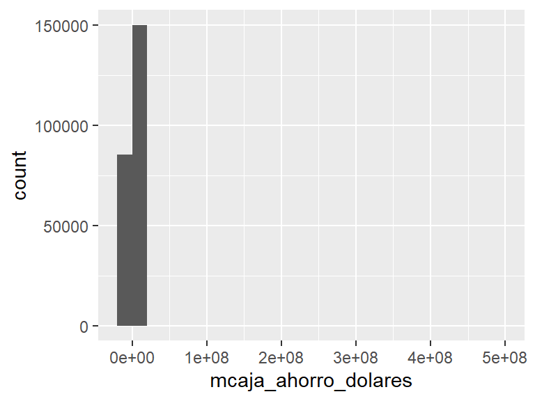

- Note that the following possible outlier values were detected: “-17291.97”, “-12477.46”, “-10684.27”, “-8912.47”, “-5988.29”, “-5259.25”, “-3662.13”, “-3564.99”, “-3130.95”, “-2228.11” (5510 additional values omitted).

## mdescubierto_preacordado

- Note that this variable is treated as a factor variable below, as it only takes a few unique values.

| Feature | Result |
| --- | --- |
| Variable type | numeric |
| Number of missing obs. | 0 (0 %) |
| Number of unique values | 2 |
| Mode | “1.17” |
| Reference category | 0 |

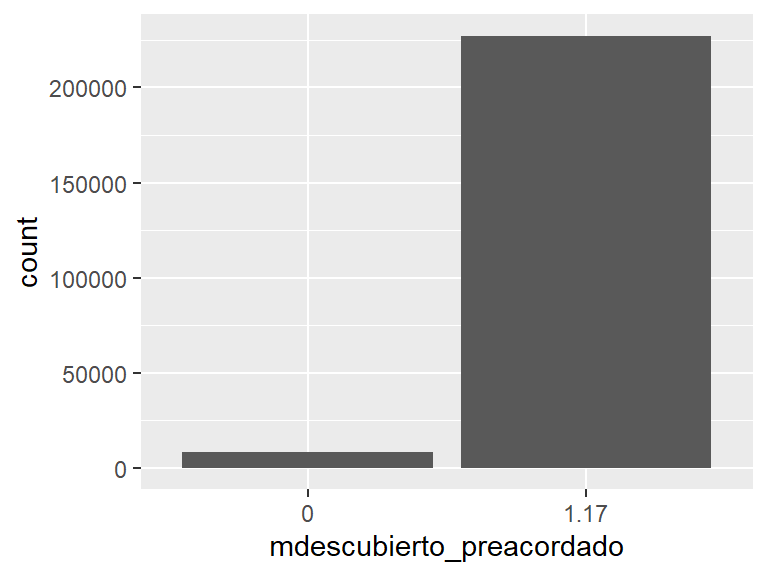

## mcuentas_saldo

| Feature | Result |
| --- | --- |
| Variable type | numeric |
| Number of missing obs. | 0 (0 %) |
| Number of unique values | 229001 |
| Median | 35259.65 |
| 1st and 3rd quartiles | 1697.03; 127661.95 |
| Min. and max. | -22235111.26; 408800085.16 |

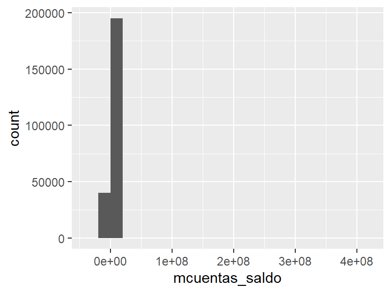

- Note that the following possible outlier values were detected: “-22235111.26”, “-2712995.09”, “-2060485.11”, “-1779437.08”, “-1690057.14”, “-1479333.88”, “-1411840.35”, “-1389578.86”, “-1286606”, “-1277894.8” (11189 additional values omitted).

## ctarjeta_debito

| Feature | Result |
| --- | --- |
| Variable type | integer |
| Number of missing obs. | 0 (0 %) |
| Number of unique values | 16 |
| Median | 1 |
| 1st and 3rd quartiles | 1; 2 |
| Min. and max. | 0; 114 |

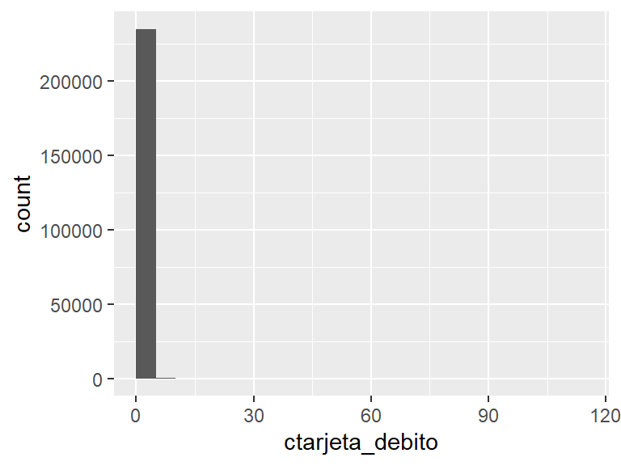

- Note that the following possible outlier values were detected: “0”, “52”, “114”.

## ctarjeta_debito_transacciones

| Feature | Result |
| --- | --- |
| Variable type | integer |
| Number of missing obs. | 0 (0 %) |
| Number of unique values | 113 |
| Median | 3 |
| 1st and 3rd quartiles | 0; 9 |
| Min. and max. | 0; 148 |

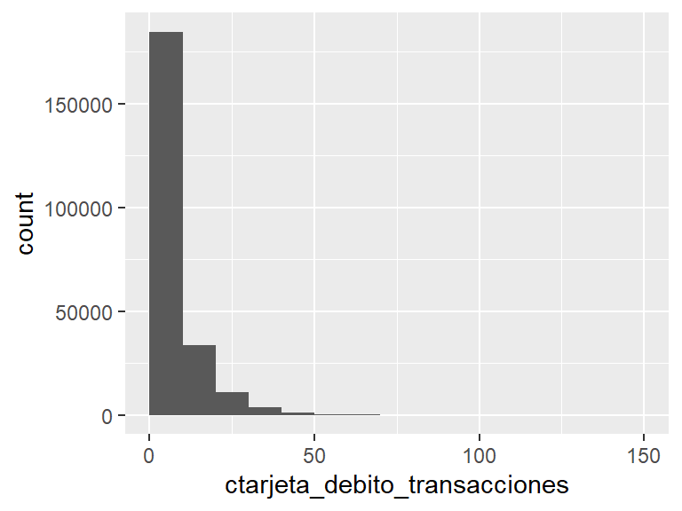

- Note that the following possible outlier values were detected: “62”, “63”, “64”, “65”, “66”, “67”, “68”, “69”, “70”, “71” (41 additional values omitted).

## mautoservicio

| Feature | Result |
| --- | --- |
| Variable type | numeric |
| Number of missing obs. | 0 (0 %) |
| Number of unique values | 131125 |
| Median | 4182.86 |
| 1st and 3rd quartiles | 0; 16547.38 |
| Min. and max. | 0; 980059.27 |

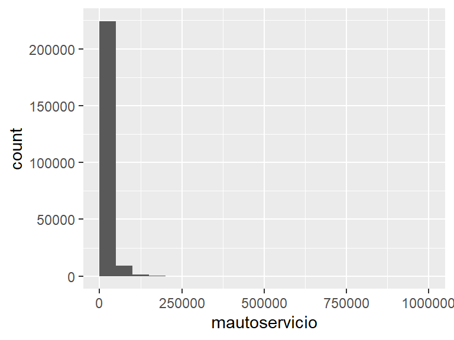

- Note that the following possible outlier values were detected: “152597.01”, “152607.61”, “152761.22”, “153010.41”, “153011.11”, “153011.99”, “153043.58”, “153054.84”, “153170.23”, “153256.97” (507 additional values omitted).

## ctarjeta_visa

- Note that this variable is treated as a factor variable below, as it only takes a few unique values.

| Feature | Result |
| --- | --- |
| Variable type | integer |
| Number of missing obs. | 0 (0 %) |
| Number of unique values | 5 |
| Mode | “1” |
| Reference category | 0 |

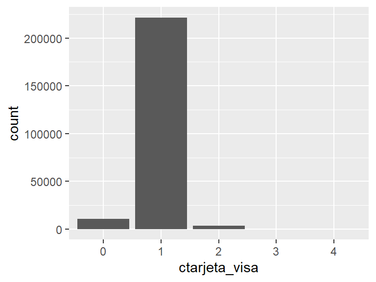

- Note that the following levels have at most five observations: “4”.

## ctarjeta_visa_transacciones

| Feature | Result |
| --- | --- |
| Variable type | integer |
| Number of missing obs. | 0 (0 %) |
| Number of unique values | 188 |
| Median | 8 |
| 1st and 3rd quartiles | 3; 17 |
| Min. and max. | 0; 1200 |

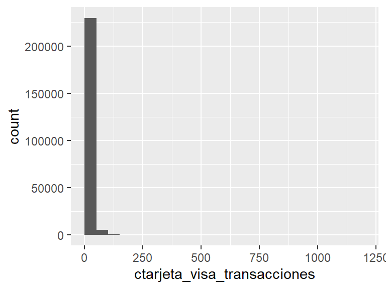

- Note that the following possible outlier values were detected: “75”, “76”, “77”, “78”, “79”, “80”, “81”, “82”, “83”, “84” (103 additional values omitted).

## mtarjeta_visa_consumo

| Feature | Result |
| --- | --- |
| Variable type | numeric |
| Number of missing obs. | 0 (0 %) |
| Number of unique values | 190752 |
| Median | 15190.58 |
| 1st and 3rd quartiles | 3924.43; 34989.85 |
| Min. and max. | 0; 3029631.55 |

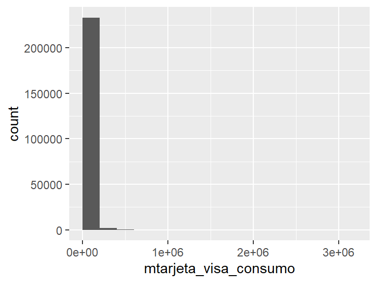

- Note that the following possible outlier values were detected: “177112.8”, “177135.19”, “177187.53”, “177201.81”, “177214.49”, “177219.92”, “177249.75”, “177273.98”, “177287.66”, “177320.39” (2918 additional values omitted).

## ctarjeta_master

- Note that this variable is treated as a factor variable below, as it only takes a few unique values.

| Feature | Result |
| --- | --- |
| Variable type | integer |
| Number of missing obs. | 0 (0 %) |
| Number of unique values | 4 |
| Mode | “1” |
| Reference category | 0 |

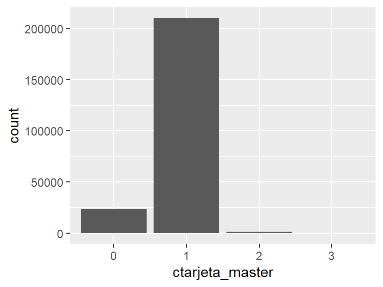

## ctarjeta_master_transacciones

| Feature | Result |
| --- | --- |
| Variable type | integer |
| Number of missing obs. | 0 (0 %) |
| Number of unique values | 116 |
| Median | 0 |
| 1st and 3rd quartiles | 0; 2 |
| Min. and max. | 0; 347 |

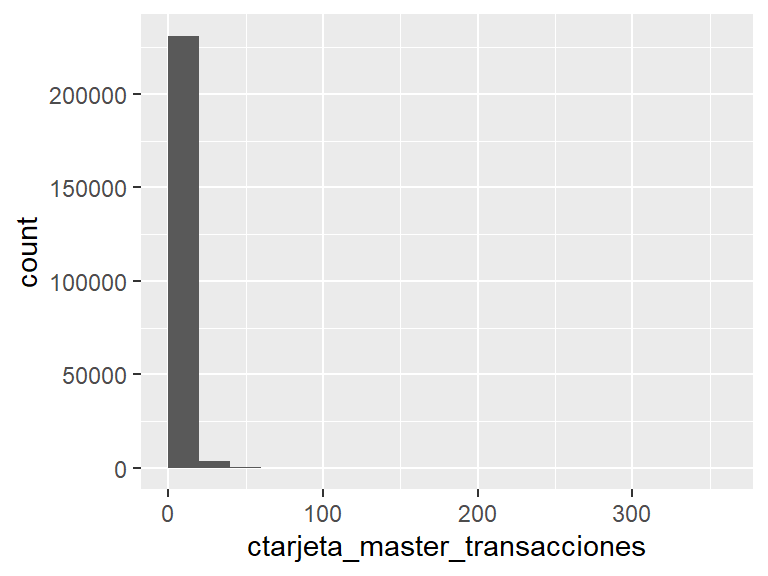

- Note that the following possible outlier values were detected: “63”, “64”, “65”, “66”, “67”, “68”, “69”, “70”, “71”, “72” (43 additional values omitted).

## mtarjeta_master_consumo

| Feature | Result |
| --- | --- |
| Variable type | numeric |
| Number of missing obs. | 0 (0 %) |
| Number of unique values | 73066 |
| Median | 0 |
| 1st and 3rd quartiles | 0; 3253.88 |
| Min. and max. | 0; 2685909.76 |

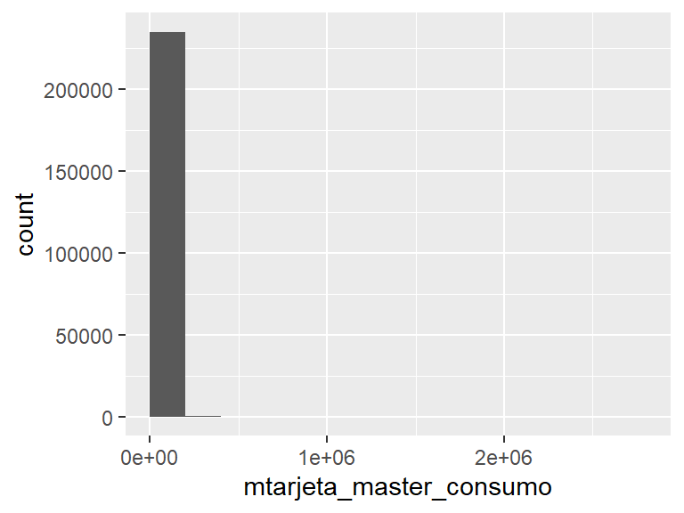

- Note that the following possible outlier values were detected: “101307.98”, “101364.76”, “101383.22”, “101388.35”, “101389.23”, “101415.98”, “101429.05”, “101433.87”, “101514.89”, “101536.26” (1704 additional values omitted).

## cprestamos_personales

| Feature | Result |
| --- | --- |
| Variable type | integer |
| Number of missing obs. | 0 (0 %) |
| Number of unique values | 114 |
| Median | 0 |
| 1st and 3rd quartiles | 0; 0 |
| Min. and max. | 0; 372 |

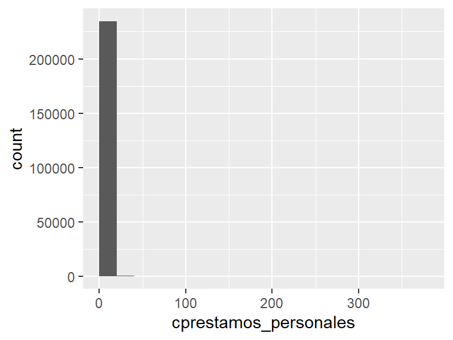

- Note that the following possible outlier values were detected: “1”, “2”, “3”, “4”, “5”, “6”, “7”, “8”, “9”, “10” (103 additional values omitted).

## mprestamos_personales

| Feature | Result |
| --- | --- |
| Variable type | numeric |
| Number of missing obs. | 0 (0 %) |
| Number of unique values | 44859 |
| Median | 0 |
| 1st and 3rd quartiles | 0; 0 |
| Min. and max. | 0; 3538621.34 |

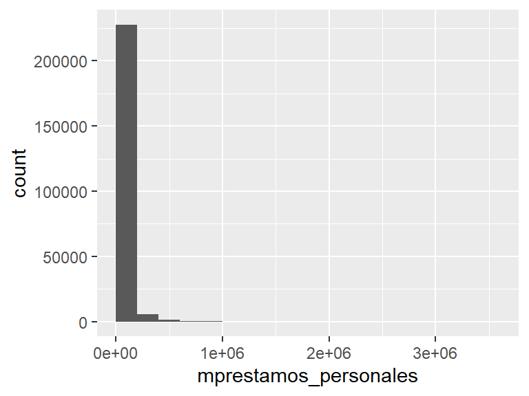

- Note that the following possible outlier values were detected: “94.67”, “103.76”, “138.18”, “141.59”, “154.76”, “172.16”, “173.62”, “191.47”, “218.95”, “263.02” (44848 additional values omitted).

## cprestamos_prendarios

| Feature | Result |
| --- | --- |
| Variable type | integer |
| Number of missing obs. | 0 (0 %) |
| Number of unique values | 12 |
| Median | 0 |
| 1st and 3rd quartiles | 0; 0 |
| Min. and max. | 0; 13 |

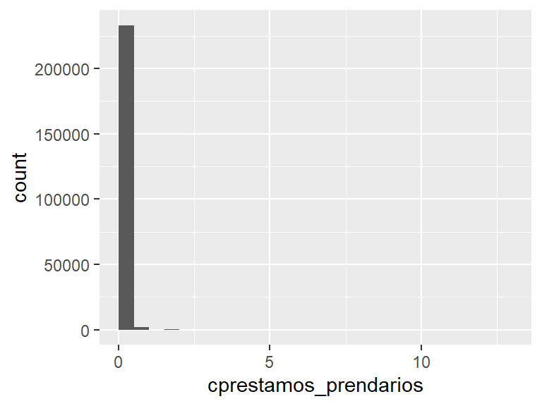

- Note that the following possible outlier values were detected: “1”, “2”, “3”, “4”, “5”, “6”, “7”, “8”, “10”, “11” (1 additional values omitted).

## mprestamos_prendarios

| Feature | Result |
| --- | --- |
| Variable type | numeric |
| Number of missing obs. | 0 (0 %) |
| Number of unique values | 2215 |
| Median | 0 |
| 1st and 3rd quartiles | 0; 0 |
| Min. and max. | -521157.78; 4752437.54 |

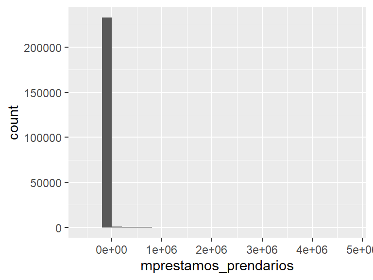

- Note that the following possible outlier values were detected: “-521157.78”, “-40408.04”, “2794.69”, “3007.53”, “3289.91”, “3389.3”, “3760.7”, “4559.38”, “4930.84”, “4963.87” (2204 additional values omitted).

## cprestamos_hipotecarios

| Feature | Result |
| --- | --- |
| Variable type | integer |
| Number of missing obs. | 0 (0 %) |
| Number of unique values | 11 |
| Median | 0 |
| 1st and 3rd quartiles | 0; 0 |
| Min. and max. | 0; 12 |

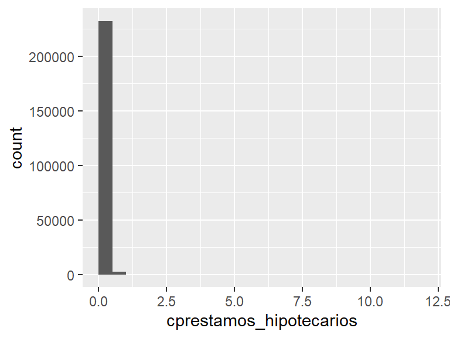

- Note that the following possible outlier values were detected: “1”, “2”, “3”, “4”, “5”, “6”, “7”, “8”, “10”, “12”.

## mprestamos_hipotecarios

| Feature | Result |
| --- | --- |
| Variable type | numeric |
| Number of missing obs. | 0 (0 %) |
| Number of unique values | 2905 |
| Median | 0 |
| 1st and 3rd quartiles | 0; 0 |
| Min. and max. | 0; 27549270.75 |

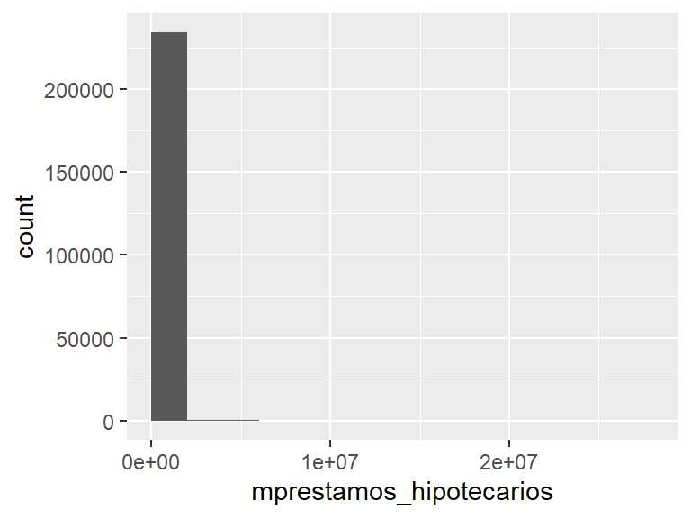

- Note that the following possible outlier values were detected: “391.95”, “469.17”, “750.63”, “1295.9”, “1466.01”, “1725.93”, “1879.02”, “1887.58”, “1908.48”, “2014.42” (2894 additional values omitted).

## cplazo_fijo

| Feature | Result |
| --- | --- |
| Variable type | integer |
| Number of missing obs. | 0 (0 %) |
| Number of unique values | 53 |
| Median | 0 |
| 1st and 3rd quartiles | 0; 0 |
| Min. and max. | 0; 88 |

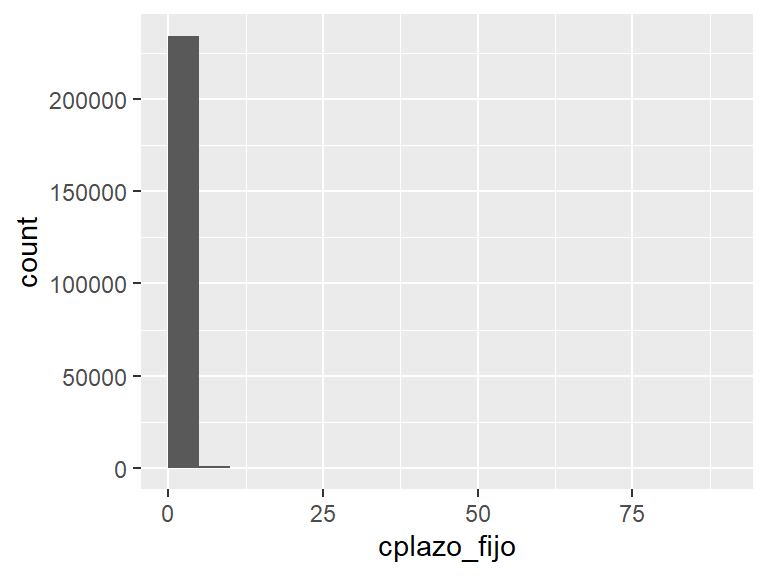

- The following suspected missing value codes enter as regular values: “88”.
- Note that the following possible outlier values were detected: “1”, “2”, “3”, “4”, “5”, “6”, “7”, “8”, “9”, “10” (42 additional values omitted).

## mplazo_fijo_dolares

| Feature | Result |
| --- | --- |
| Variable type | numeric |
| Number of missing obs. | 0 (0 %) |
| Number of unique values | 8137 |
| Median | 0 |
| 1st and 3rd quartiles | 0; 0 |
| Min. and max. | 0; 70422300 |

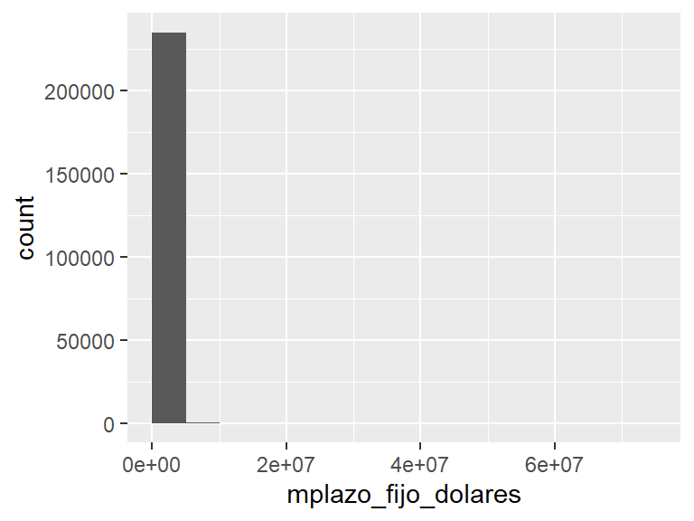

- Note that the following possible outlier values were detected: “585”, “601.38”, “607.56”, “640.7”, “673.51”, “677.86”, “696.15”, “711.79”, “714.92”, “716.16” (8126 additional values omitted).

## mplazo_fijo_pesos

| Feature | Result |
| --- | --- |
| Variable type | numeric |
| Number of missing obs. | 0 (0 %) |
| Number of unique values | 781 |
| Median | 0 |
| 1st and 3rd quartiles | 0; 0 |
| Min. and max. | 0; 26676215.01 |

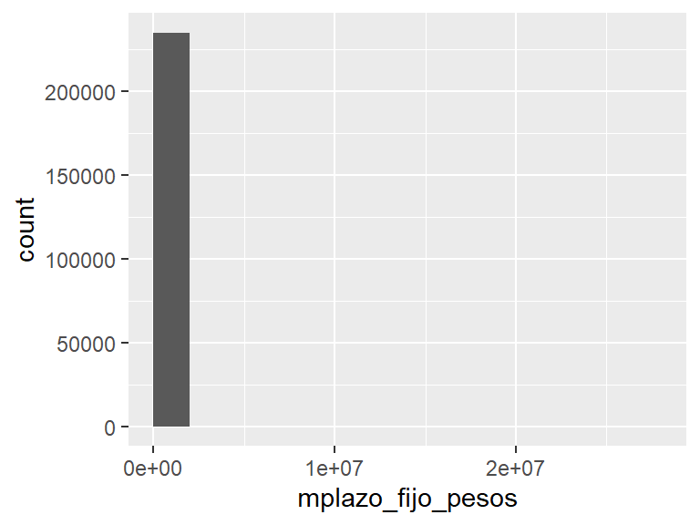

- Note that the following possible outlier values were detected: “44562.37”, “44564.15”, “44567.72”, “44569.5”, “44573.06”, “44579.3”, “44580.2”, “44581.98”, “44587.33”, “44589.1” (770 additional values omitted).

## cinversion1

| Feature | Result |
| --- | --- |
| Variable type | integer |
| Number of missing obs. | 0 (0 %) |
| Number of unique values | 15 |
| Median | 0 |
| 1st and 3rd quartiles | 0; 0 |
| Min. and max. | 0; 15 |

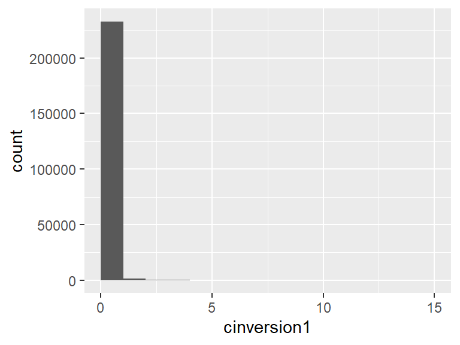

- Note that the following possible outlier values were detected: “1”, “2”, “3”, “4”, “5”, “6”, “7”, “8”, “9”, “10” (4 additional values omitted).

## minversion1_pesos

| Feature | Result |
| --- | --- |
| Variable type | numeric |
| Number of missing obs. | 0 (0 %) |
| Number of unique values | 8175 |
| Median | 0 |
| 1st and 3rd quartiles | 0; 0 |
| Min. and max. | 0; 166139999.98 |

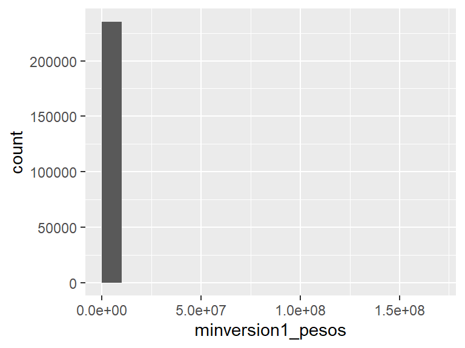

- Note that the following possible outlier values were detected: “0.08”, “1.28”, “1.5”, “1.91”, “2.19”, “2.31”, “2.32”, “2.35”, “2.66”, “2.7” (8164 additional values omitted).

## minversion1_dolares

| Feature | Result |
| --- | --- |
| Variable type | numeric |
| Number of missing obs. | 0 (0 %) |
| Number of unique values | 1032 |
| Median | 0 |
| 1st and 3rd quartiles | 0; 0 |
| Min. and max. | 0; 43873181.32 |

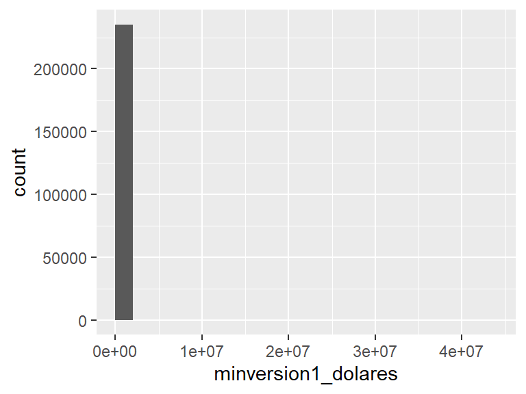

- Note that the following possible outlier values were detected: “94.47”, “102.49”, “105.17”, “106.06”, “123.87”, “159.52”, “179.13”, “186.27”, “196.08”, “204.98” (1021 additional values omitted).

## cinversion2

| Feature | Result |
| --- | --- |
| Variable type | integer |
| Number of missing obs. | 0 (0 %) |
| Number of unique values | 46 |
| Median | 0 |
| 1st and 3rd quartiles | 0; 0 |
| Min. and max. | 0; 53 |

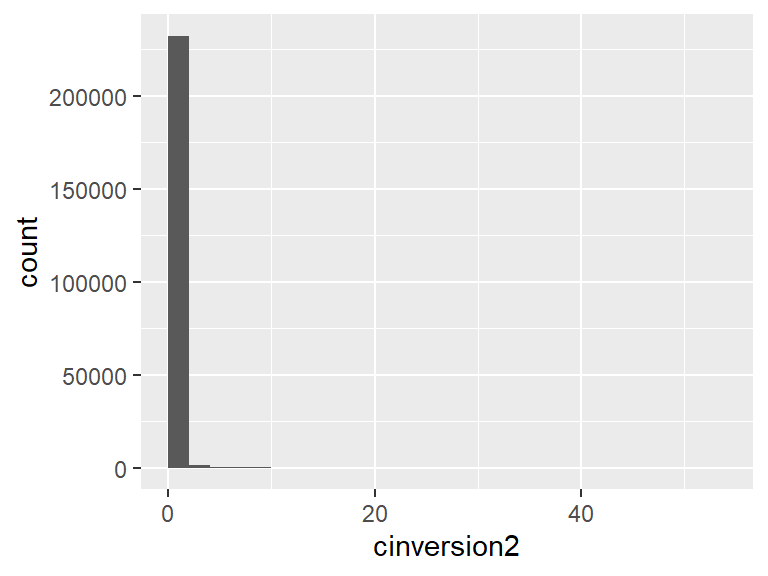

- Note that the following possible outlier values were detected: “1”, “2”, “3”, “4”, “5”, “6”, “7”, “8”, “9”, “10” (35 additional values omitted).

## minversion2

| Feature | Result |
| --- | --- |
| Variable type | numeric |
| Number of missing obs. | 0 (0 %) |
| Number of unique values | 7577 |
| Median | 0 |
| 1st and 3rd quartiles | 0; 0 |
| Min. and max. | 0; 772692679.07 |

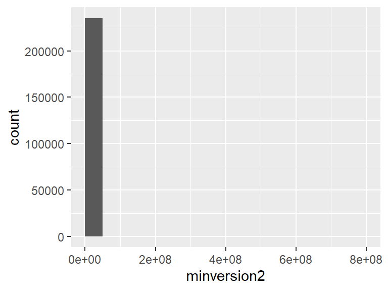

- Note that the following possible outlier values were detected: “0.01”, “0.02”, “0.03”, “0.05”, “0.07”, “0.08”, “0.09”, “0.1”, “0.12”, “0.14” (7566 additional values omitted).

## cseguro_vida

| Feature | Result |
| --- | --- |
| Variable type | integer |
| Number of missing obs. | 0 (0 %) |
| Number of unique values | 6 |
| Median | 0 |
| 1st and 3rd quartiles | 0; 0 |
| Min. and max. | 0; 5 |

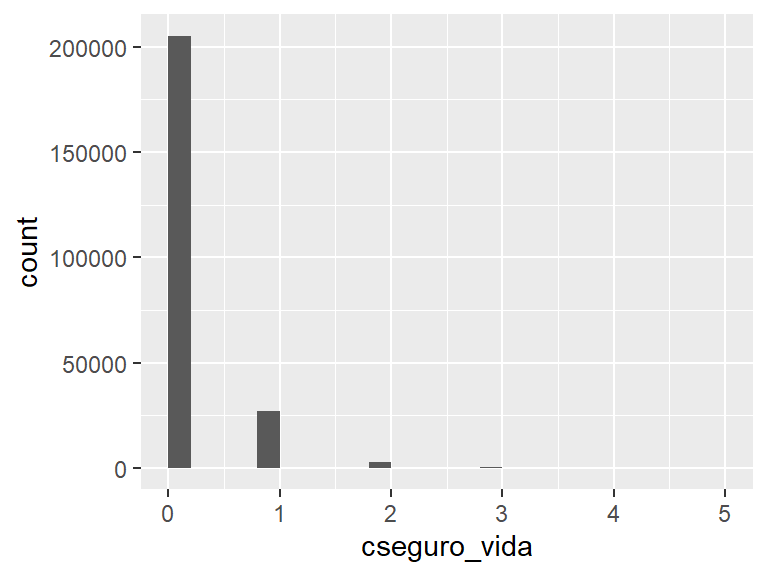

- Note that the following possible outlier values were detected: “1”, “2”, “3”, “4”, “5”.

## cseguro_auto

| Feature | Result |
| --- | --- |
| Variable type | integer |
| Number of missing obs. | 0 (0 %) |
| Number of unique values | 7 |
| Median | 0 |
| 1st and 3rd quartiles | 0; 0 |
| Min. and max. | 0; 7 |

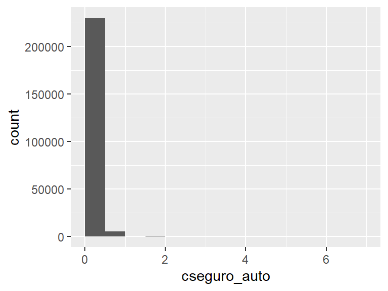

- Note that the following possible outlier values were detected: “1”, “2”, “3”, “4”, “5”, “7”.

## cseguro_vivienda

| Feature | Result |
| --- | --- |
| Variable type | integer |
| Number of missing obs. | 0 (0 %) |
| Number of unique values | 7 |
| Median | 0 |
| 1st and 3rd quartiles | 0; 0 |
| Min. and max. | 0; 7 |

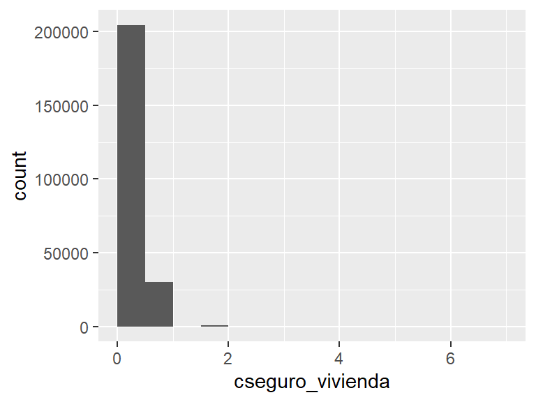

- Note that the following possible outlier values were detected: “1”, “2”, “3”, “4”, “5”, “7”.

## cseguro_accidentes_personales

- Note that this variable is treated as a factor variable below, as it only takes a few unique values.

| Feature | Result |
| --- | --- |
| Variable type | integer |
| Number of missing obs. | 0 (0 %) |
| Number of unique values | 4 |
| Mode | “0” |
| Reference category | 0 |

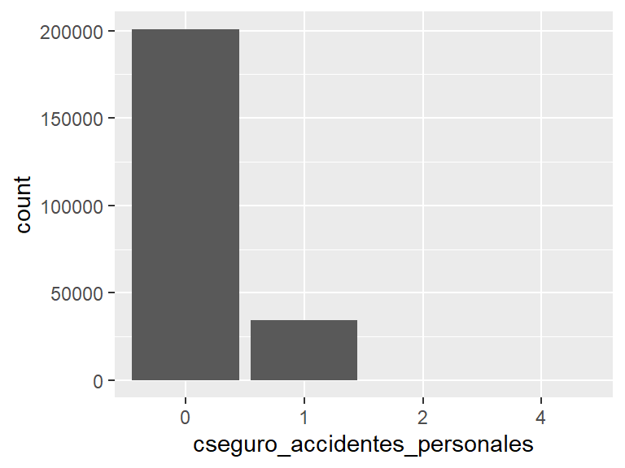

- Note that the following levels have at most five observations: “4”.

## ccaja_seguridad

| Feature | Result |
| --- | --- |
| Variable type | integer |
| Number of missing obs. | 0 (0 %) |
| Number of unique values | 7 |
| Median | 0 |
| 1st and 3rd quartiles | 0; 0 |
| Min. and max. | 0; 6 |

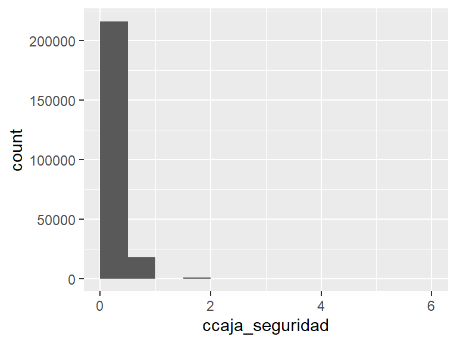

- Note that the following possible outlier values were detected: “1”, “2”, “3”, “4”, “5”, “6”.

## cpayroll_trx

| Feature | Result |
| --- | --- |
| Variable type | integer |
| Number of missing obs. | 0 (0 %) |
| Number of unique values | 34 |
| Median | 1 |
| 1st and 3rd quartiles | 0; 1 |
| Min. and max. | 0; 54 |

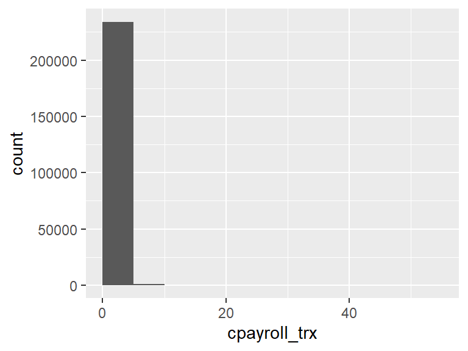

- Note that the following possible outlier values were detected: “3”, “4”, “5”, “6”, “7”, “8”, “9”, “10”, “11”, “12” (21 additional values omitted).

## mpayroll

| Feature | Result |
| --- | --- |
| Variable type | numeric |
| Number of missing obs. | 0 (0 %) |
| Number of unique values | 102556 |
| Median | 4000.72 |
| 1st and 3rd quartiles | 0; 76670.1 |
| Min. and max. | 0; 34364677.23 |

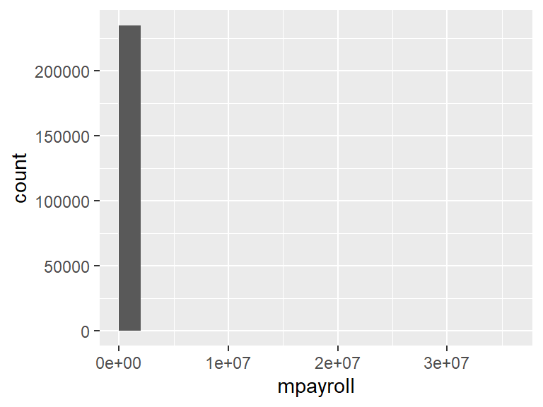

- Note that the following possible outlier values were detected: “1769940.9”, “1770229.89”, “1770943.94”, “1778031.45”, “1780114.05”, “1781297.57”, “1783042.77”, “1789613.06”, “1812511.99”, “1828695.96” (248 additional values omitted).

## mpayroll2

| Feature | Result |
| --- | --- |
| Variable type | numeric |
| Number of missing obs. | 0 (0 %) |
| Number of unique values | 200 |
| Median | 0 |
| 1st and 3rd quartiles | 0; 0 |
| Min. and max. | 0; 360094.41 |

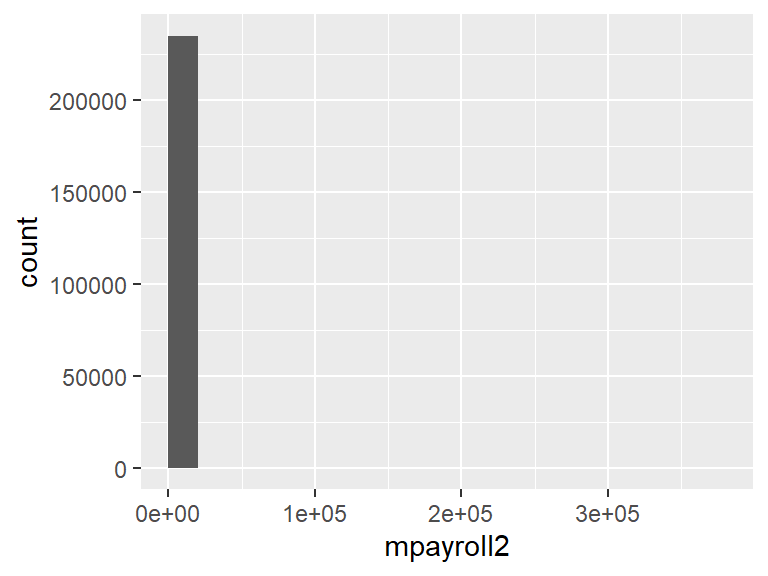

- Note that the following possible outlier values were detected: “1002.69”, “1170”, “1689.48”, “2340”, “2682.35”, “3110.44”, “4095”, “4374.63”, “4680”, “4797” (189 additional values omitted).

## cpayroll2_trx

- Note that this variable is treated as a factor variable below, as it only takes a few unique values.

| Feature | Result |
| --- | --- |
| Variable type | integer |
| Number of missing obs. | 0 (0 %) |
| Number of unique values | 5 |
| Mode | “0” |
| Reference category | 0 |

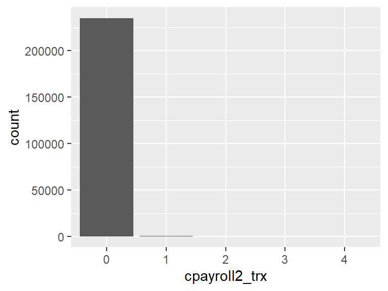

## ccuenta_debitos_automaticos

| Feature | Result |
| --- | --- |
| Variable type | integer |
| Number of missing obs. | 0 (0 %) |
| Number of unique values | 41 |
| Median | 0 |
| 1st and 3rd quartiles | 0; 1 |
| Min. and max. | 0; 88 |

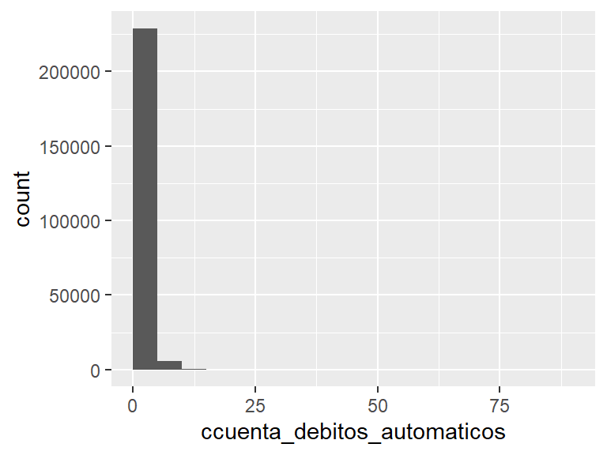

- The following suspected missing value codes enter as regular values: “88”.
- Note that the following possible outlier values were detected: “32”, “34”, “35”, “36”, “40”, “41”, “44”, “46”, “62”, “88”.

## mcuenta_debitos_automaticos

| Feature | Result |
| --- | --- |
| Variable type | numeric |
| Number of missing obs. | 0 (0 %) |
| Number of unique values | 75053 |
| Median | 0 |
| 1st and 3rd quartiles | 0; 2994.82 |
| Min. and max. | 0; 26566471.65 |

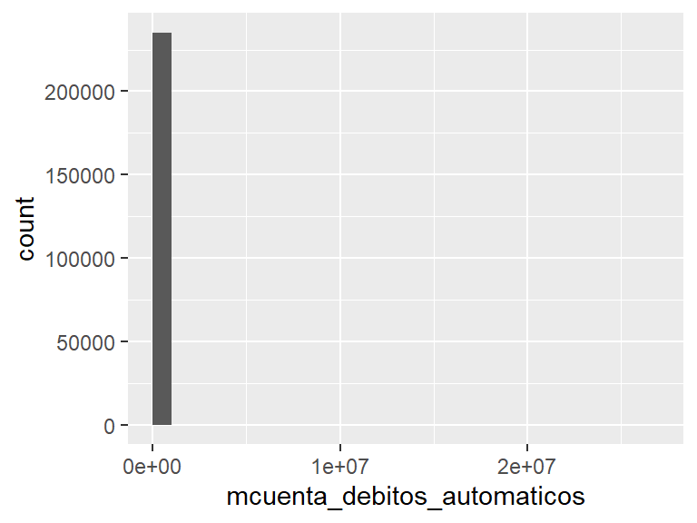

- Note that the following possible outlier values were detected: “93240.3”, “93274.56”, “93292.86”, “93302.97”, “93355.23”, “93416.75”, “93507.74”, “93561.15”, “93605.8”, “93626.68” (1748 additional values omitted).

## ctarjeta_visa_debitos_automaticos

| Feature | Result |
| --- | --- |
| Variable type | integer |
| Number of missing obs. | 0 (0 %) |
| Number of unique values | 45 |
| Median | 1 |
| 1st and 3rd quartiles | 0; 4 |
| Min. and max. | 0; 60 |

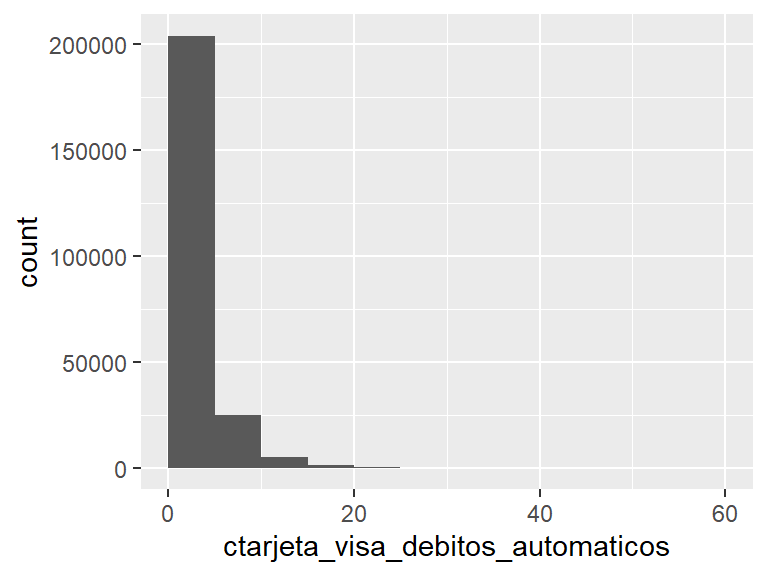

- Note that the following possible outlier values were detected: “31”, “32”, “33”, “34”, “35”, “36”, “37”, “38”, “41”, “42” (4 additional values omitted).

## mttarjeta_visa_debitos_automaticos

| Feature | Result |
| --- | --- |
| Variable type | numeric |
| Number of missing obs. | 0 (0 %) |
| Number of unique values | 117032 |
| Median | 1453.3 |
| 1st and 3rd quartiles | 0; 7058.59 |
| Min. and max. | 0; 405263.76 |

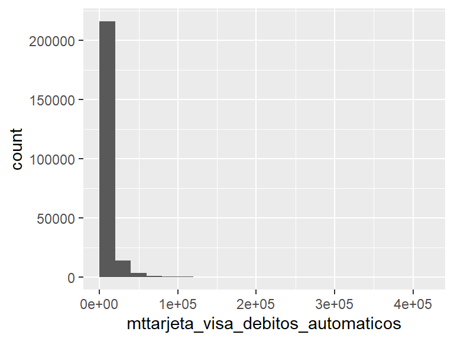

- Note that the following possible outlier values were detected: “79536.49”, “79562.41”, “79606.47”, “79612.87”, “79674.4”, “79680.81”, “79701.16”, “79792.25”, “79846.01”, “79860.24” (762 additional values omitted).

## ctarjeta_master_debitos_automaticos

| Feature | Result |
| --- | --- |
| Variable type | integer |
| Number of missing obs. | 0 (0 %) |
| Number of unique values | 28 |
| Median | 0 |
| 1st and 3rd quartiles | 0; 0 |
| Min. and max. | 0; 54 |

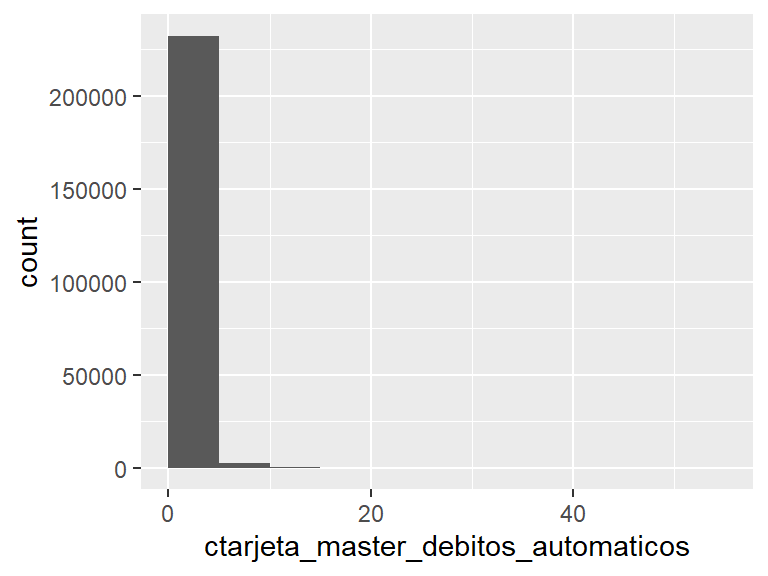

- Note that the following possible outlier values were detected: “1”, “2”, “3”, “4”, “5”, “6”, “7”, “8”, “9”, “10” (17 additional values omitted).

## mttarjeta_master_debitos_automaticos

| Feature | Result |
| --- | --- |
| Variable type | numeric |
| Number of missing obs. | 0 (0 %) |
| Number of unique values | 27387 |
| Median | 0 |
| 1st and 3rd quartiles | 0; 0 |
| Min. and max. | 0; 372698.01 |

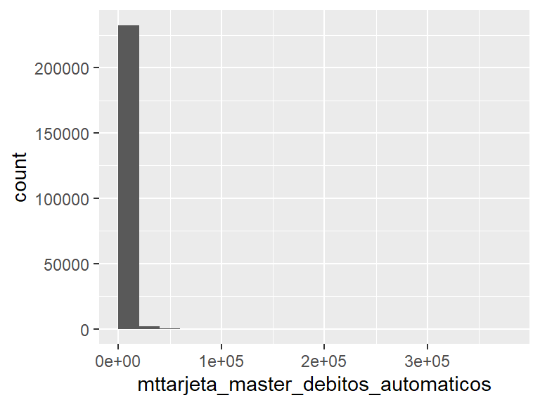

- Note that the following possible outlier values were detected: “1.27”, “1.63”, “1.68”, “1.75”, “1.89”, “2.01”, “2.04”, “2.46”, “2.55”, “2.59” (27376 additional values omitted).

## cpagodeservicios

| Feature | Result |
| --- | --- |
| Variable type | integer |
| Number of missing obs. | 0 (0 %) |
| Number of unique values | 23 |
| Median | 0 |
| 1st and 3rd quartiles | 0; 0 |
| Min. and max. | 0; 39 |

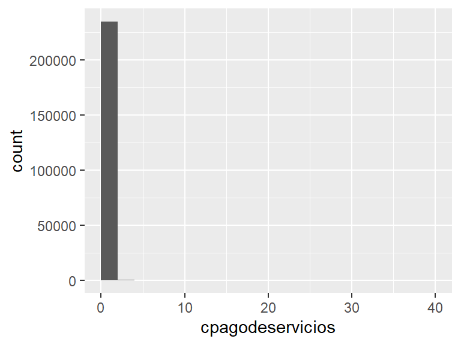

- Note that the following possible outlier values were detected: “1”, “2”, “3”, “4”, “5”, “6”, “7”, “8”, “9”, “10” (12 additional values omitted).

## mpagodeservicios

| Feature | Result |
| --- | --- |
| Variable type | numeric |
| Number of missing obs. | 0 (0 %) |
| Number of unique values | 1827 |
| Median | 0 |
| 1st and 3rd quartiles | 0; 0 |
| Min. and max. | 0; 5583955.33 |

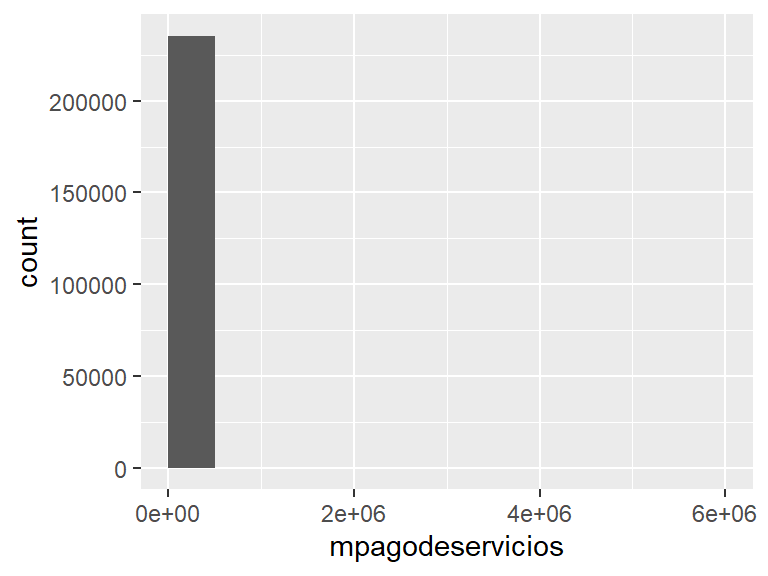

- Note that the following possible outlier values were detected: “6.32”, “22.37”, “23.4”, “35.27”, “55.91”, “58.5”, “70.2”, “93.6”, “117”, “140.4” (1816 additional values omitted).